# Analysis for results

```r
library(lubridate)
library(tidyverse)
library(ggplot2)
```

Pull file

```r
atlantic_croaker_final <- read_csv("data/atlantic_croaker_final.csv")
View(atlantic_croaker_final)
```

Make new columns to answer hypothesis

```r
atlantic_croaker_final <- atlantic_croaker_final %>%
  mutate(aspect_ratio=(Caudheight/Caudarea)^(1/2), square_caudal_peduncle_depth_factor=(Cauddepth/Depthatpec)^2,
         Year=year(Tow_date), Month=month(Tow_date))
View(atlantic_croaker_final)
```

Structure 1. Type question 2. Make plot 3. Run statistical test 4. Answer question

#Question set to answer first main question relating morphological traits within the years/location

Hypothesis: Fish from 1995 will have a higher total length and aspect ratio, and a lower square caudal peduncle depth factor compared to fish from 2017.

```r
#Make dataframe for 1995 & 2017 fish
##in order to create statistical tests
atcroaker95 <- atlantic_croaker_final %>%
  filter(Year==1995)

atcroaker17 <- atlantic_croaker_final %>%
  filter(Year==2017)
```

Question 1: Is aspect ratio higher in fish from 1995 than fish from 2017?

```r
#Statistical test
wilcox.test(x=atcroaker95$aspect_ratio, y=atcroaker17$aspect_ratio, alternative = c("two.sided"))
```

```
    Wilcoxon rank sum test with continuity correction

data:  atcroaker95$aspect_ratio and atcroaker17$aspect_ratio
W = 11969, p-value = 0.08456
alternative hypothesis: true location shift is not equal to 0
```

Question 2: Does fish from 1995 have a higher total length measurement than fish from 2017?

```r
#Statistical analysis
wilcox.test(x=atcroaker95$Totallength, y=atcroaker17$Totallength , alternative=c("two.sided"))
```

```
    Wilcoxon rank sum test with continuity correction

data:  atcroaker95$Totallength and atcroaker17$Totallength
W = 10499, p-value = 0.7748
alternative hypothesis: true location shift is not equal to 0
```

Question 3: Is square caudal peduncle depth factor lower in fish from 1995 than fish from 2017?

```r
#Statistical analysis
wilcox.test(x=atcroaker95$square_caudal_peduncle_depth_factor,  y=atcroaker17$square_caudal_peduncle_depth_factor, alternative = c("two.sided"))
```

```
    Wilcoxon rank sum test with continuity correction

data:  atcroaker95$square_caudal_peduncle_depth_factor and atcroaker17$square_caudal_peduncle_depth_factor
W = 10012, p-value = 0.3407
alternative hypothesis: true location shift is not equal to 0
```

In summary, there is no significance whether location influence morphological traits

#Question set 2 relating morphological traits and temperature within the years Question 1 Aspect ratio

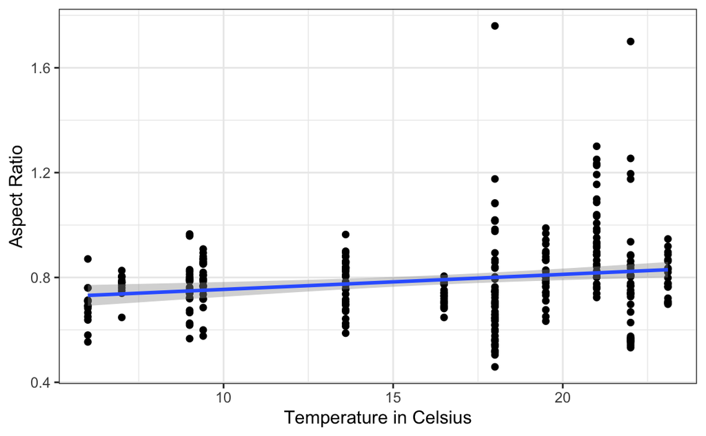

p-value: 0.001113

Question 2 How does Total length vary with temperature?

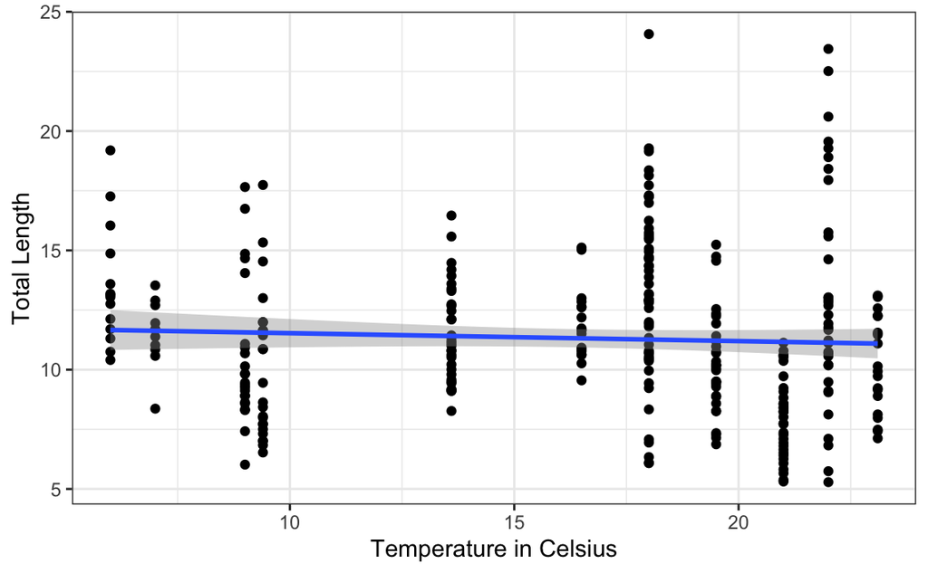

p-value: 0.3649 not a significant relationship

Question 3 How does Square caudal peduncle depth factor vary with temperature?

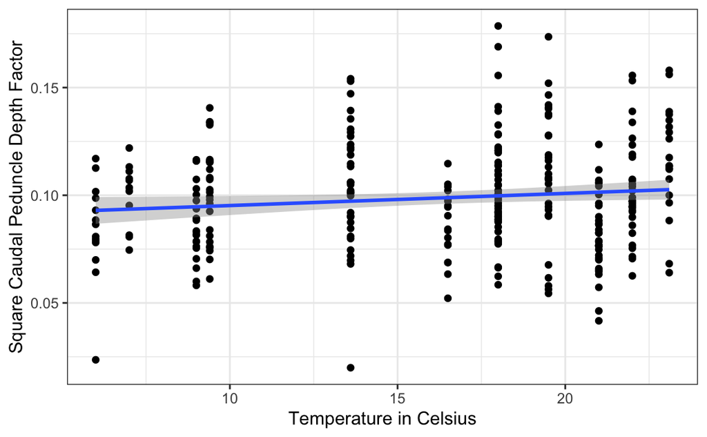

p-value: 0.03942

Other questions: #Question set 3 Does the month the fish got caught influence in their total length measurement?

```r
#Plot
ggplot(data=atlantic_croaker_final) +
  geom_point(aes(x=Month, y=Totallength, color=factor(Month)))

#Statistical analysis
wilcox.test(x= atcroaker95$Totallength,  y= atcroaker17$Totallength, alternative = c("two.sided"))
```

[output not shown]

```r
#Plot
ggplot(data=atlantic_croaker_final) +
  geom_point(aes(x=Month, y=Bodyarea, color=factor(Month)))

#Statistical test
wilcox.test(x=atcroaker95$Bodyarea, y=atcroaker17$Bodyarea, alternative = c("two.sided"))
```

[output not shown]

```r
#Plot
ggplot(data = atlantic_croaker_final) +
  geom_point(aes(x=Month, y=aspect_ratio, color=factor(Month)))

#Statistical analysis
wilcox.test(x=atcroaker95$aspect_ratio, y=atcroaker17$aspect_ratio, alternative = c("two.sided"))
```

[output not shown]

```r
#Plot
ggplot(data = atlantic_croaker_final) +
  geom_point(aes(x=Month, y=square_caudal_peduncle_depth_factor, color=factor(Month)))

#Statistical analysis
wilcox.test(x=atcroaker95$square_caudal_peduncle_depth_factor, y=atcroaker17$square_caudal_peduncle_depth_factor, alternative = c("two.sided"))
```

[output not shown]